# Kmeans_submission (3)

### SVC-BASED CLASSIFICATION WITH A TABULAR VECTOR BORNE DISEASE DATASET

#### TEAM MEMBERS:

- #### Maryam Jahangir (11159172)
- #### Niels Schwung (11160885)
- #### Nnamdi Ogbonnaya Odii (11160333)

#### 1.0 The Problem

Classification with a Tabular Vector Borne Disease Dataset is the 2023 edition of Kaggle's Playground Series Competition. The goal of this competition is to develop robust machine learning models that can accurately classify instances of vector-borne diseases based on a tabular dataset containing various features. Participants are expected to preprocess and analyze the dataset, perform feature engineering if necessary, and train machine learning models using various algorithms and techniques. The models should be able to generalize well to unseen data and provide accurate predictions on the test set.

Our task is to train the Support Vector Machine classifier(SVC), evaluate its performance using the map@k and then predict on an unseen dataset, likely top_3 vector borne diseases, given some features.

#### 2.0 The Dataset

Two datasets were provided for this task: the train dataset, labeled as train.csv and the test.csv, for prediction purpose.

#### 2.0.1 Train.csv

- The train dataset consists of 707x64 features (symptoms) and 707x1 labels (prognosis).
- The features are binary digits (0s and 1s) where 0 represents absence of a particular symptom and 1 represents its presence. Each feature column is depicted by a particular symptom.
- The labels are string-values of different kinds of vector borne diseases. This target variable serves as the ground truth for training the classification model.

#### 2.0.2 Test.csv

- The Test.csv dataset consists of 303x64 features (symptoms).
- The test dataset is also a tabular dataset that follows a similar structure to the training dataset.
- However, unlike the training dataset, the test dataset does not contain the target variable.
- The purpose of the test dataset is to evaluate the performance and generalization ability of the machine learning model developed.
- By uploading the predictions for the test dataset to Kaggle, a MAPK score for the test.csv is obtained.

#### 3.0 The Preprocessing Methods

#### 3.0.1 Feature Engingeering

Feature engineering is the process of transforming raw data into a format that is suitable for machine learning algorithms to extract meaningful patterns and make accurate predictions. It involves creating new features or modifying existing features in the dataset to enhance the performance of a machine learning model.

We did the following preprocessing activities on the data based on the solution handed in to Kaggle by R.J. Zhang [1]:

$\chi^{2}=\sum \frac{\left({O}_{i}-E_{i}\right)^{2}}{E_{i}}$

$\chi^2 $= chi squared, ${O}_i $= observed value, $E_{i} $= expected value

#### 3.0.2 Hyperparameter Tuning

We applied the surrogate model optimization-based hyperparameter tuning approach based on the Python version of SPOT. This enabled us to tune the default values of the SVC hyperparameters to obtain best values within the defined search space and number of evaluations.

#### The SVC Hyperparameters

- C: This is the regularization parameter that controls the trade-off between maximizing the margin and minimizing the classification error. A smaller value of C allows for a larger margin but may misclassify more training examples.
- Kernel: The kernel function maps the input data into a higher-dimensional space to make it linearly separable. It could be linear, polynomial, RBF or sigmoid.
- Degree: It specifies the order of the polynomial used to transform the data.
- gamma: Used for other kernels but linear. It controls the influence of each training example. Higher values of gamma will result in a more complex decision boundary, potentially overfitting the training data.
- coeff0: It affects the influence of high-degree polynomials compared to low-degree ones.
- shrinking: This is a boolean parameter that can speed up training for large datasets but may slightly increase the prediction time.
- probability: If set to True, the predict_proba method can be used to obtain class probabilities.
- tol: It determines the stopping criterion for the optimization solver.
- cache_size: The kernel cache is used to store computed kernel values and can speed up training for larger datasets.
- break_ties: This is a boolean parameter that specifies how to handle ties when predicting class labels.

#### 4.0 Results

We carried out some evaluations on the provided data. First evaluations were done using the default hyperparameter values while the second evaluations were carried out using tuned parameters. Both evaluations were done using 10-fold cross validation on the train and test subsets as well as on the complete dataset.

The following results were obtained:

```
* Default values:
    * map@k           : 0.38
    * Train           : 0.36
    * Test            : 0.29
    * Complete Data   : 0.37

* Tuned values:
    * map@k           : 0.39
    * Train           : 0.36
    * Test            : 0.31
    * Complete Data   : 0.37
```

Also, using the trained classifier, we made prediction on the test.csv and obtained top3 probabilities for each sample.

Our result was submitted to Kaggle and otained the following result:

[figure not shown]

```python
from IPython.display import Image
Image("Kaggle_Submission_DDMO.JPG")
```

*Image 1: Results of the Kaggle Submission*

#### 5.0 Discussion and Conclusion

Further investigations are possible to yield even better results. Such investigations could consist of using different feature engineering methods, selection techniques (like RFE) as well as hyperparameter tuners like optuna or random search.

#### 6.0 References

[1]https://www.kaggle.com/competitions/playground-series-s3e13/discussion/407829

[2]https://git-ce.rwth-aachen.de/spotseven-lab/ddmo-ait-sommersemester-2023/-/blob/main/Notebooks.d/18_spot_hpt_sklearn_multiclass_classification_svc.ipynb

[3]https://sequential-parameter-optimization.github.io/spotPython/01_spot_intro.html

#### 7.0 Code

#### 1.0 Import the necessary libraries

```python
#!pip install tabulate
#tabulate may not be installed by default

from tabulate import tabulate
import warnings
import numpy as np
from math import inf
import pandas as pd
import random

from scipy.optimize import differential_evolution
import matplotlib.pyplot as plt
from sklearn.preprocessing import OneHotEncoder , MinMaxScaler, StandardScaler
from sklearn.preprocessing import OrdinalEncoder
from sklearn.pipeline import make_pipeline , Pipeline
from sklearn.compose import ColumnTransformer
from sklearn.model_selection import cross_validate
from sklearn.datasets import fetch_openml
from sklearn.datasets import make_classification
from sklearn.model_selection import train_test_split
from sklearn.svm import SVC
from sklearn.preprocessing import LabelEncoder
import itertools
from sklearn.feature_selection import chi2
from sklearn.feature_selection import SelectKBest


from spotPython.utils.convert import class_for_name
from spotPython.utils.eda import (
    get_stars,
    gen_design_table)
from spotPython.utils.transform import transform_hyper_parameter_values
from spotPython.utils.convert import get_Xy_from_df
from spotPython.plot.validation import plot_cv_predictions, plot_roc, plot_confusion_matrix
from spotPython.utils.init import fun_control_init
from spotPython.data.sklearn_hyper_dict import SklearnHyperDict
from spotPython.fun.hypersklearn import HyperSklearn
from spotPython.utils.metrics import mapk_score
from spotPython.spot import spot
from spotPython.hyperparameters.values import (
    add_core_model_to_fun_control,
    assign_values,
    convert_keys,
    get_bound_values,
    get_default_hyperparameters_for_core_model,
    get_default_values,
    get_default_hyperparameters_as_array,
    get_dict_with_levels_and_types,
    get_values_from_dict,
    get_var_name,
    get_var_type,
    iterate_dict_values,
    modify_hyper_parameter_levels,
    modify_hyper_parameter_bounds,
    replace_levels_with_positions,
    return_conf_list_from_var_dict,
    get_one_core_model_from_X,
    transform_hyper_parameter_values,
    get_dict_with_levels_and_types,
    convert_keys,
    iterate_dict_values,
    get_one_sklearn_model_from_X
)
warnings.filterwarnings("ignore")
```

[output not shown]

#### 2.0 Load the Training dataset

```python
# Set a random seed for reproducibility
np.random.seed(42)
```

```python
dataset = pd.read_csv('train.csv')
    # remove the id column
dataset = dataset.drop(columns=['id'])
n_samples = dataset.shape[0] # Number of samples/rows in the dataset(707)
n_features = dataset.shape[1] - 1 # Number of features/columns in the dataset(64)
target_column = "prognosis" # The target column name
```

#### 3.0 Feature Engingeering

#### 3.0.1(a) Encoding the target_coulmn string values to integer values

```python
enc = OrdinalEncoder() #Creates an instance of the OrdinalEncoder class.
dataset[target_column] = enc.fit_transform(dataset[[target_column]]) #Fits & transforms the target_column to integer values.
dataset.columns = [f"x{i}" for i in range(1, n_features+1)] + [target_column]#Assigns new column names to the dataset.
print(dataset.shape)
dataset.head()
```

```
(707, 65)
```

|  | x1 | x2 | x3 | x4 | x5 | x6 | x7 | x8 | x9 | x10 | ... | x56 | x57 | x58 | x59 | x60 | x61 | x62 | x63 | x64 | prognosis |
| --- | --- | --- | --- | --- | --- | --- | --- | --- | --- | --- | --- | --- | --- | --- | --- | --- | --- | --- | --- | --- | --- |
| 0 | 1.0 | 1.0 | 0.0 | 1.0 | 1.0 | 1.0 | 1.0 | 0.0 | 1.0 | 1.0 | ... | 0.0 | 0.0 | 0.0 | 0.0 | 0.0 | 0.0 | 0.0 | 0.0 | 0.0 | 3.0 |
| 1 | 0.0 | 0.0 | 0.0 | 0.0 | 0.0 | 0.0 | 1.0 | 0.0 | 1.0 | 0.0 | ... | 0.0 | 0.0 | 0.0 | 0.0 | 0.0 | 0.0 | 0.0 | 0.0 | 0.0 | 7.0 |
| 2 | 0.0 | 1.0 | 1.0 | 1.0 | 0.0 | 1.0 | 1.0 | 1.0 | 1.0 | 1.0 | ... | 1.0 | 1.0 | 1.0 | 1.0 | 1.0 | 0.0 | 1.0 | 1.0 | 1.0 | 3.0 |
| 3 | 0.0 | 0.0 | 1.0 | 1.0 | 1.0 | 1.0 | 0.0 | 1.0 | 0.0 | 1.0 | ... | 0.0 | 0.0 | 0.0 | 0.0 | 0.0 | 0.0 | 0.0 | 0.0 | 0.0 | 10.0 |
| 4 | 0.0 | 0.0 | 0.0 | 0.0 | 0.0 | 0.0 | 0.0 | 0.0 | 1.0 | 0.0 | ... | 0.0 | 1.0 | 0.0 | 0.0 | 1.0 | 1.0 | 1.0 | 0.0 | 0.0 | 6.0 |

5 rows × 65 columns

#### 3.0.1(b) Feature Combination

```python
y_col = dataset ['prognosis']
dataset = dataset.drop(columns=['prognosis'])
dataset = dataset.astype(int)#Ensures that all the feature elements are represented as integers.
for col1, col2 in itertools.combinations(dataset.columns,2):#Uses the combinations function from the itertools module to generate pairs of column names.
    dataset[f'{col1}_and_{col2}'] = dataset[col1] & dataset[col2]#creates a new column in the dataset between the values in col1 and col2
    dataset[f'{col1}_or_{col2}'] = dataset[col1] | dataset[col2]#creates another new column in the dataset between the values in col1 and col2
    dataset[f'{col1}_xor_{col2}'] = dataset[col1] ^ dataset[col2]#creates yet another new column in the dataset between the values in col1 and col2

dataset
```

|  | x1 | x2 | x3 | x4 | x5 | x6 | x7 | x8 | x9 | x10 | ... | x61_xor_x64 | x62_and_x63 | x62_or_x63 | x62_xor_x63 | x62_and_x64 | x62_or_x64 | x62_xor_x64 | x63_and_x64 | x63_or_x64 | x63_xor_x64 |
| --- | --- | --- | --- | --- | --- | --- | --- | --- | --- | --- | --- | --- | --- | --- | --- | --- | --- | --- | --- | --- | --- |
| 0 | 1 | 1 | 0 | 1 | 1 | 1 | 1 | 0 | 1 | 1 | ... | 0 | 0 | 0 | 0 | 0 | 0 | 0 | 0 | 0 | 0 |
| 1 | 0 | 0 | 0 | 0 | 0 | 0 | 1 | 0 | 1 | 0 | ... | 0 | 0 | 0 | 0 | 0 | 0 | 0 | 0 | 0 | 0 |
| 2 | 0 | 1 | 1 | 1 | 0 | 1 | 1 | 1 | 1 | 1 | ... | 1 | 1 | 1 | 0 | 1 | 1 | 0 | 1 | 1 | 0 |
| 3 | 0 | 0 | 1 | 1 | 1 | 1 | 0 | 1 | 0 | 1 | ... | 0 | 0 | 0 | 0 | 0 | 0 | 0 | 0 | 0 | 0 |
| 4 | 0 | 0 | 0 | 0 | 0 | 0 | 0 | 0 | 1 | 0 | ... | 1 | 0 | 1 | 1 | 0 | 1 | 1 | 0 | 0 | 0 |
| ... | ... | ... | ... | ... | ... | ... | ... | ... | ... | ... | ... | ... | ... | ... | ... | ... | ... | ... | ... | ... | ... |
| 702 | 0 | 0 | 1 | 1 | 1 | 0 | 0 | 0 | 0 | 0 | ... | 0 | 0 | 0 | 0 | 0 | 0 | 0 | 0 | 0 | 0 |
| 703 | 1 | 0 | 1 | 1 | 1 | 1 | 0 | 1 | 1 | 0 | ... | 0 | 0 | 0 | 0 | 0 | 0 | 0 | 0 | 0 | 0 |
| 704 | 1 | 0 | 1 | 0 | 1 | 0 | 0 | 1 | 1 | 1 | ... | 0 | 0 | 0 | 0 | 0 | 0 | 0 | 0 | 0 | 0 |
| 705 | 1 | 1 | 0 | 0 | 1 | 0 | 1 | 0 | 1 | 0 | ... | 0 | 0 | 0 | 0 | 0 | 0 | 0 | 0 | 0 | 0 |
| 706 | 1 | 1 | 0 | 0 | 0 | 0 | 1 | 0 | 0 | 0 | ... | 1 | 0 | 1 | 1 | 0 | 1 | 1 | 0 | 0 | 0 |

707 rows × 6112 columns

#### 3.0.1(c) Feature Aggregation

```python
#This code block creates new columns in the dataset DataFrame by extracting subsets of columns based on specific substrings
#('pain', 'inflammation', 'bleed', 'skin'). It calculates the sum of the values in each subset of columns across rows and
#assigns the results to the corresponding new columns. This process allows aggregating related information from multiple
#columns into single columns, potentially capturing important patterns or information in the dataset.

cols_A = dataset.columns[dataset.columns.str.contains('pain')]#creates a new variable cols_A and assigns it the column names from the dataset DataFrame that contain the substring 'pain'
cols_B = dataset.columns[dataset.columns.str.contains('inflammation')]
cols_C = dataset.columns[dataset.columns.str.contains('bleed')]
cols_D = dataset.columns[dataset.columns.str.contains('skin')]
dataset['cols_A'] = dataset[cols_A].sum(axis=1)#Calculates the sum of the columns specified by cols_A across each row using the sum method with axis=1. The result is assigned to the new column,cols_A
dataset['cols_B'] = dataset[cols_B].sum(axis=1)
dataset['cols_C'] = dataset[cols_C].sum(axis=1)
dataset['cols_D'] = dataset[cols_D].sum(axis=1)
dataset1 = dataset
dataset1
```

|  | x1 | x2 | x3 | x4 | x5 | x6 | x7 | x8 | x9 | x10 | ... | x62_and_x64 | x62_or_x64 | x62_xor_x64 | x63_and_x64 | x63_or_x64 | x63_xor_x64 | cols_A | cols_B | cols_C | cols_D |
| --- | --- | --- | --- | --- | --- | --- | --- | --- | --- | --- | --- | --- | --- | --- | --- | --- | --- | --- | --- | --- | --- |
| 0 | 1 | 1 | 0 | 1 | 1 | 1 | 1 | 0 | 1 | 1 | ... | 0 | 0 | 0 | 0 | 0 | 0 | 0.0 | 0.0 | 0.0 | 0.0 |
| 1 | 0 | 0 | 0 | 0 | 0 | 0 | 1 | 0 | 1 | 0 | ... | 0 | 0 | 0 | 0 | 0 | 0 | 0.0 | 0.0 | 0.0 | 0.0 |
| 2 | 0 | 1 | 1 | 1 | 0 | 1 | 1 | 1 | 1 | 1 | ... | 1 | 1 | 0 | 1 | 1 | 0 | 0.0 | 0.0 | 0.0 | 0.0 |
| 3 | 0 | 0 | 1 | 1 | 1 | 1 | 0 | 1 | 0 | 1 | ... | 0 | 0 | 0 | 0 | 0 | 0 | 0.0 | 0.0 | 0.0 | 0.0 |
| 4 | 0 | 0 | 0 | 0 | 0 | 0 | 0 | 0 | 1 | 0 | ... | 0 | 1 | 1 | 0 | 0 | 0 | 0.0 | 0.0 | 0.0 | 0.0 |
| ... | ... | ... | ... | ... | ... | ... | ... | ... | ... | ... | ... | ... | ... | ... | ... | ... | ... | ... | ... | ... | ... |
| 702 | 0 | 0 | 1 | 1 | 1 | 0 | 0 | 0 | 0 | 0 | ... | 0 | 0 | 0 | 0 | 0 | 0 | 0.0 | 0.0 | 0.0 | 0.0 |
| 703 | 1 | 0 | 1 | 1 | 1 | 1 | 0 | 1 | 1 | 0 | ... | 0 | 0 | 0 | 0 | 0 | 0 | 0.0 | 0.0 | 0.0 | 0.0 |
| 704 | 1 | 0 | 1 | 0 | 1 | 0 | 0 | 1 | 1 | 1 | ... | 0 | 0 | 0 | 0 | 0 | 0 | 0.0 | 0.0 | 0.0 | 0.0 |
| 705 | 1 | 1 | 0 | 0 | 1 | 0 | 1 | 0 | 1 | 0 | ... | 0 | 0 | 0 | 0 | 0 | 0 | 0.0 | 0.0 | 0.0 | 0.0 |
| 706 | 1 | 1 | 0 | 0 | 0 | 0 | 1 | 0 | 0 | 0 | ... | 0 | 1 | 1 | 0 | 0 | 0 | 0.0 | 0.0 | 0.0 | 0.0 |

707 rows × 6116 columns

```python
dataset1['prognosis'] = y_col# Adds the 'prognosis' column to the modified dataset1 DataFrame.
dataset = dataset1
dataset
```

|  | x1 | x2 | x3 | x4 | x5 | x6 | x7 | x8 | x9 | x10 | ... | x62_or_x64 | x62_xor_x64 | x63_and_x64 | x63_or_x64 | x63_xor_x64 | cols_A | cols_B | cols_C | cols_D | prognosis |
| --- | --- | --- | --- | --- | --- | --- | --- | --- | --- | --- | --- | --- | --- | --- | --- | --- | --- | --- | --- | --- | --- |
| 0 | 1 | 1 | 0 | 1 | 1 | 1 | 1 | 0 | 1 | 1 | ... | 0 | 0 | 0 | 0 | 0 | 0.0 | 0.0 | 0.0 | 0.0 | 3.0 |
| 1 | 0 | 0 | 0 | 0 | 0 | 0 | 1 | 0 | 1 | 0 | ... | 0 | 0 | 0 | 0 | 0 | 0.0 | 0.0 | 0.0 | 0.0 | 7.0 |
| 2 | 0 | 1 | 1 | 1 | 0 | 1 | 1 | 1 | 1 | 1 | ... | 1 | 0 | 1 | 1 | 0 | 0.0 | 0.0 | 0.0 | 0.0 | 3.0 |
| 3 | 0 | 0 | 1 | 1 | 1 | 1 | 0 | 1 | 0 | 1 | ... | 0 | 0 | 0 | 0 | 0 | 0.0 | 0.0 | 0.0 | 0.0 | 10.0 |
| 4 | 0 | 0 | 0 | 0 | 0 | 0 | 0 | 0 | 1 | 0 | ... | 1 | 1 | 0 | 0 | 0 | 0.0 | 0.0 | 0.0 | 0.0 | 6.0 |
| ... | ... | ... | ... | ... | ... | ... | ... | ... | ... | ... | ... | ... | ... | ... | ... | ... | ... | ... | ... | ... | ... |
| 702 | 0 | 0 | 1 | 1 | 1 | 0 | 0 | 0 | 0 | 0 | ... | 0 | 0 | 0 | 0 | 0 | 0.0 | 0.0 | 0.0 | 0.0 | 5.0 |
| 703 | 1 | 0 | 1 | 1 | 1 | 1 | 0 | 1 | 1 | 0 | ... | 0 | 0 | 0 | 0 | 0 | 0.0 | 0.0 | 0.0 | 0.0 | 4.0 |
| 704 | 1 | 0 | 1 | 0 | 1 | 0 | 0 | 1 | 1 | 1 | ... | 0 | 0 | 0 | 0 | 0 | 0.0 | 0.0 | 0.0 | 0.0 | 10.0 |
| 705 | 1 | 1 | 0 | 0 | 1 | 0 | 1 | 0 | 1 | 0 | ... | 0 | 0 | 0 | 0 | 0 | 0.0 | 0.0 | 0.0 | 0.0 | 5.0 |
| 706 | 1 | 1 | 0 | 0 | 0 | 0 | 1 | 0 | 0 | 0 | ... | 1 | 1 | 0 | 0 | 0 | 0.0 | 0.0 | 0.0 | 0.0 | 7.0 |

707 rows × 6117 columns

#### 3.0.1(d) Feature Subset Selection

```python
y = dataset[target_column]
X = dataset.drop(columns=[target_column], axis = 1)
selector = SelectKBest(score_func=chi2, k=200)
selector.fit(X, y)#Fits the feature selector to the data.
```

```
SelectKBest(k=200, score_func=<function chi2 at 0x1518099ddc60>)
```

```python
# Get the selected feature indices and names
selected_indices = selector.get_support(indices=True)
selected_features = X.columns[selected_indices]
len(selected_features)
```

```
200
```

```python
# Filter the dataset with the selected features
selected_data = dataset[selected_features]#Creates a new dataframe containing only the selected features
selected_data['prognosis'] = y_col #copies the target variable (prognosis) into the selected_data DataFrame.
#selected_data = selected_data.copy()
selected_data
```

|  | x36 | x60 | x61 | x62 | x2_and_x56 | x2_and_x58 | x3_and_x56 | x3_and_x58 | x3_and_x59 | x14_and_x28 | ... | x61_or_x62 | x61_or_x63 | x61_xor_x63 | x61_or_x64 | x61_xor_x64 | x62_or_x63 | x62_xor_x63 | x62_or_x64 | x62_xor_x64 | prognosis |
| --- | --- | --- | --- | --- | --- | --- | --- | --- | --- | --- | --- | --- | --- | --- | --- | --- | --- | --- | --- | --- | --- |
| 0 | 0 | 0 | 0 | 0 | 0 | 0 | 0 | 0 | 0 | 0 | ... | 0 | 0 | 0 | 0 | 0 | 0 | 0 | 0 | 0 | 3.0 |
| 1 | 0 | 0 | 0 | 0 | 0 | 0 | 0 | 0 | 0 | 0 | ... | 0 | 0 | 0 | 0 | 0 | 0 | 0 | 0 | 0 | 7.0 |
| 2 | 1 | 1 | 0 | 1 | 1 | 1 | 1 | 1 | 1 | 1 | ... | 1 | 1 | 1 | 1 | 1 | 1 | 0 | 1 | 0 | 3.0 |
| 3 | 0 | 0 | 0 | 0 | 0 | 0 | 0 | 0 | 0 | 1 | ... | 0 | 0 | 0 | 0 | 0 | 0 | 0 | 0 | 0 | 10.0 |
| 4 | 0 | 1 | 1 | 1 | 0 | 0 | 0 | 0 | 0 | 0 | ... | 1 | 1 | 1 | 1 | 1 | 1 | 1 | 1 | 1 | 6.0 |
| ... | ... | ... | ... | ... | ... | ... | ... | ... | ... | ... | ... | ... | ... | ... | ... | ... | ... | ... | ... | ... | ... |
| 702 | 1 | 0 | 0 | 0 | 0 | 0 | 0 | 0 | 0 | 1 | ... | 0 | 0 | 0 | 0 | 0 | 0 | 0 | 0 | 0 | 5.0 |
| 703 | 1 | 0 | 0 | 0 | 0 | 0 | 0 | 0 | 0 | 0 | ... | 0 | 0 | 0 | 0 | 0 | 0 | 0 | 0 | 0 | 4.0 |
| 704 | 1 | 0 | 0 | 0 | 0 | 0 | 0 | 0 | 0 | 0 | ... | 0 | 0 | 0 | 0 | 0 | 0 | 0 | 0 | 0 | 10.0 |
| 705 | 0 | 0 | 0 | 0 | 1 | 1 | 0 | 0 | 0 | 0 | ... | 0 | 0 | 0 | 0 | 0 | 0 | 0 | 0 | 0 | 5.0 |
| 706 | 0 | 1 | 1 | 1 | 0 | 0 | 0 | 0 | 0 | 0 | ... | 1 | 1 | 1 | 1 | 1 | 1 | 1 | 1 | 1 | 7.0 |

707 rows × 201 columns

#### 4.0 Splitting the selected_data into train & test subsets

```python
#Stratified splitting helps to maintain the same class distribution as in the original dataset, providing a more reliable evaluation of the model's performance.

n_samples = selected_data.shape[0]
n_features = selected_data.shape[1] - 1
target_column = "prognosis"
train_df = selected_data

X_train, X_test, y_train, y_test = train_test_split(train_df.drop(target_column, axis=1), train_df[target_column],
                                                    random_state=42,
                                                    test_size=0.25,
                                                    stratify=train_df[target_column])
train = pd.DataFrame(np.hstack((X_train, np.array(y_train).reshape(-1, 1)))) #converts the target variable y_train into a 2D array with a single column, so that it can be concatenated with X_train
test = pd.DataFrame(np.hstack((X_test, np.array(y_test).reshape(-1, 1))))
train.columns = [f"x{i}" for i in range(1, n_features + 1)] + [target_column]
test.columns = [f"x{i}" for i in range(1, n_features + 1)] + [target_column]
```

```python
print(train.shape)
print(test.shape)
train.head()
```

```
(530, 201)
(177, 201)
```

|  | x1 | x2 | x3 | x4 | x5 | x6 | x7 | x8 | x9 | x10 | ... | x192 | x193 | x194 | x195 | x196 | x197 | x198 | x199 | x200 | prognosis |
| --- | --- | --- | --- | --- | --- | --- | --- | --- | --- | --- | --- | --- | --- | --- | --- | --- | --- | --- | --- | --- | --- |
| 0 | 1.0 | 0.0 | 0.0 | 0.0 | 0.0 | 0.0 | 0.0 | 0.0 | 0.0 | 0.0 | ... | 0.0 | 0.0 | 0.0 | 0.0 | 0.0 | 0.0 | 0.0 | 0.0 | 0.0 | 2.0 |
| 1 | 0.0 | 0.0 | 0.0 | 0.0 | 0.0 | 0.0 | 0.0 | 0.0 | 0.0 | 0.0 | ... | 0.0 | 0.0 | 0.0 | 0.0 | 0.0 | 0.0 | 0.0 | 0.0 | 0.0 | 4.0 |
| 2 | 0.0 | 1.0 | 1.0 | 1.0 | 0.0 | 0.0 | 0.0 | 0.0 | 0.0 | 0.0 | ... | 1.0 | 1.0 | 1.0 | 1.0 | 0.0 | 1.0 | 1.0 | 1.0 | 0.0 | 1.0 |
| 3 | 1.0 | 0.0 | 0.0 | 0.0 | 0.0 | 0.0 | 0.0 | 0.0 | 0.0 | 0.0 | ... | 0.0 | 0.0 | 0.0 | 0.0 | 0.0 | 0.0 | 0.0 | 0.0 | 0.0 | 6.0 |
| 4 | 1.0 | 0.0 | 0.0 | 0.0 | 0.0 | 0.0 | 0.0 | 0.0 | 0.0 | 0.0 | ... | 0.0 | 0.0 | 0.0 | 0.0 | 0.0 | 0.0 | 0.0 | 0.0 | 0.0 | 5.0 |

5 rows × 201 columns

#### 5.0 Initialize fun_control dictionary

```python
# Initialize fun_control dictionary
fun_control = fun_control_init(task="classification")

# add the dataset to the fun_control
fun_control.update({"data": train_df, # full dataset,
               "train": train,
               "test": test,
               "n_samples": n_samples,
               "target_column": target_column})
```

### 6.0 Assigning the SVC algorithm to the Core_Model

#### The SVM Classifier

A Support Vector Machine (SVM) classifier is a supervised machine learning algorithm used for classification tasks. It is used to separate data points into different classes by creating a hyperplane in a high-dimensional feature space. The main objective of an SVM classifier is to find the optimal hyperplane that maximally separates the data points belonging to different classes. This hyperplane is defined as the decision boundary that maximizes the margin, which is the distance between the hyperplane and the nearest data points of each class.

The 'add_core_model_to_fun_control' function is used to update the fun_control dictionary with the specified core model and its associated hyperparameter dictionary.

```python
core_model=SVC
fun_control = add_core_model_to_fun_control(core_model=core_model,
                              fun_control=fun_control,
                              hyper_dict=SklearnHyperDict,
                              filename=None)
```

```python
print(*fun_control["core_model_hyper_dict"].keys(), sep="\n")#Printing the SVC hyperparameters
```

```
C
kernel
degree
gamma
coef0
shrinking
probability
tol
cache_size
break_ties
```

```python
fun_control = modify_hyper_parameter_levels(fun_control, "kernel", ["rbf"])
fun_control = modify_hyper_parameter_bounds(fun_control, "probability", bounds=[1, 1])
```

#### Selecting the Metric

The mapk_score is a scoring metric commonly used in information retrieval tasks, which calculates the mean average precision at k. It is often used for evaluating ranked predictions, where k represents the number of predicted items to consider.The fun_control dictionary is then updated with these metrics.

```python
fun_control.update({
               "weights": -1,#spotPython performs a minimization, therefore, metrics that should be maximized have to be multiplied by -1
               "metric_sklearn": mapk_score,#"metric_sklearn" is used for the sklearn based evaluation
               "predict_proba": True,#return the probabilities of the specific classes instead of the predicted values
               "metric_params": {"k": 3},
               })
```

### 7.0 Evaluations

#### 7.0.1 Evaluations on Default Parameters

```python
#Here, we retrieved the default hyperparameters as specified in the fun_control dictionary.

values_default = get_default_values(fun_control)
values_default = transform_hyper_parameter_values(fun_control=fun_control, hyper_parameter_values=values_default)
values_default.update({"probability": 1})#Default value for "probability" is False,set to True for the metric "mapk_score".
values_default
```

```
{'C': 1.0,
 'kernel': 'rbf',
 'degree': 3,
 'gamma': 'scale',
 'coef0': 0.0,
 'shrinking': 0,
 'probability': 1,
 'tol': 0.001,
 'cache_size': 200.0,
 'break_ties': 0}
```

Create a sequential pipeline was created where the data is first preprocessed as defined in the "prep_model" and then passed to the SVC for training and prediction. The resulting model_default is an instance of the pipeline that can be fit to data and used for making predictions.

```python
model_default = make_pipeline(fun_control["prep_model"], fun_control["core_model"](**values_default))
model_default
```

```
Pipeline(steps=[('nonetype', None),
                ('svc',
                 SVC(break_ties=0, cache_size=200.0, probability=1,
                     shrinking=0))])
```

#### Training the model

The model_default fits the pipeline(applying the sequential preprocessing steps) to the training data 'X_train, y_train' and returns the trained SVC.

```python
model_default.fit(X_train, y_train)["svc"]
```

```
SVC(break_ties=0, cache_size=200.0, probability=1, shrinking=0)
```

#### Making predictions on the test subset

The trained model_default is used to predict the probabilities of the target classes for the test data 'X_test'.The predict_proba method returns the predicted probabilities for each class. The mapk_score function compares the true target labels y_test with the predicted probabilities y_pred and computes the average precision at k (AP@k) for each sample. The MAP@k score is the average of AP@k scores across all samples.

```python
y_pred = model_default.predict_proba(X_test)
mapk = mapk_score(y_true=y_test, y_pred=y_pred, k=3)
mapk
```

```
0.3851224105461394
```

#### Cross-Validated Evaluations based on k_fold = 10

#### (a)Train subset

```python
from spotPython.sklearn.traintest import evaluate_cv
fun_control.update({
     "eval": "train_cv",
     "k_folds": 10,
})
evaluate_cv(model=model_default, fun_control=fun_control, verbose=0)
```

```
(0.3691823899371069, None)
```

#### (b)Test subset

```python
fun_control.update({
     "eval": "test_cv",
     "k_folds": 10,
})
evaluate_cv(model=model_default, fun_control=fun_control, verbose=0)
```

```
(0.2963507625272331, None)
```

#### (c)Complete data

```python
fun_control.update({
     "eval": "data_cv",
     "k_folds": 10,
})
evaluate_cv(model=model_default, fun_control=fun_control, verbose=0)
```

```
(0.3712810194500335, None)
```

#### Perform 30 runs using the default settings to obtain the mean & standard deviation

```python
def repeated_eval(n, model):
    res_values = []
    for i in range(n):
        model.fit(X_train, y_train)
        y_pred = model.predict_proba(X_test)
        res = mapk_score(y_true=y_test, y_pred=y_pred, k=3)
        res_values.append(res)
    mean_res = np.mean(res_values)
    print(f"mean_res: {mean_res}")
    std_res = np.std(res_values)
    print(f"std_res: {std_res}")
    min_res = np.min(res_values)
    print(f"min_res: {min_res}")
    max_res = np.max(res_values)
    print(f"max_res: {max_res}")
    median_res = np.median(res_values)
    print(f"median_res: {median_res}")
    return mean_res, std_res, min_res, max_res, median_res
```

```python
_ = repeated_eval(30, model_default)
```

```
mean_res: 0.38700564971751406
std_res: 0.008516323204968
min_res: 0.3662900188323917
max_res: 0.40583804143126173
median_res: 0.38841807909604514
```

### 7.0.2 Evaluations using SpotPython

Using the Spot function to tune the model Hyperparameters

```python
#Get types and variable names as well as lower and upper bounds for the hyperparameters.
var_type = get_var_type(fun_control)
var_name = get_var_name(fun_control)
fun_control.update({"var_type": var_type,
                    "var_name": var_name})

lower = get_bound_values(fun_control, "lower")
upper = get_bound_values(fun_control, "upper")
```

```python
print(gen_design_table(fun_control))
```

```
| name        | type   | default   |    lower |   upper | transform   |
|-------------|--------|-----------|----------|---------|-------------|
| C           | float  | 1.0       |   0.1    |   10    | None        |
| kernel      | factor | rbf       |   0      |    0    | None        |
| degree      | int    | 3         |   3      |    3    | None        |
| gamma       | factor | scale     |   0      |    1    | None        |
| coef0       | float  | 0.0       |   0      |    0    | None        |
| shrinking   | factor | 0         |   0      |    1    | None        |
| probability | factor | 0         |   1      |    1    | None        |
| tol         | float  | 0.001     |   0.0001 |    0.01 | None        |
| cache_size  | float  | 200.0     | 100      |  400    | None        |
| break_ties  | factor | 0         |   0      |    1    | None        |
```

```python
#Preparing the Spot Optimizer
hyper_dict=SklearnHyperDict().load()#load the predefined hyperparameters and their corresponding values
X_start = get_default_hyperparameters_as_array(fun_control, hyper_dict)# retrieves the default hyperparameter values for the specified fun_control configuration and hyper_dict
X_start # the returned value is assigned to X_start
```

```
array([[1.e+00, 2.e+00, 3.e+00, 0.e+00, 0.e+00, 0.e+00, 0.e+00, 1.e-03,
        2.e+02, 0.e+00]])
```

```python
#The interface from the sklearn setting to SPOT is provided by the function fun_sklearn
fun = HyperSklearn(seed=123, log_level=50).fun_sklearn #provides functionality for hyperparameter optimization in Sklearn model.
```

#### 9.0.2.1 Tuning the hyperparameters using spot_tuner

This code starts the hyperparameter tuning process using the SPOT framework, attempting to find the optimal hyperparameters for the given optimization function within the specified time limit.

```python
MAX_TIME = 3 # Time in minutes. Counter starts, after the initial design is evaluated. So, runtime can be larger.
INIT_SIZE = 20 # Initial number of designs to evaluate, before the surrogate is build.
spot_tuner = spot.Spot(fun=fun,
                   lower = lower,
                   upper = upper,
                   fun_evals = inf,
                   fun_repeats = 1,
                   max_time = MAX_TIME,
                   noise = False,
                   tolerance_x = np.sqrt(np.spacing(1)),
                   var_type = var_type,
                   var_name = var_name,
                   infill_criterion = "y",
                   n_points = 1,
                   seed=123,
                   log_level = 50,
                   show_models= False,
                   show_progress= True,
                   fun_control = fun_control,
                   design_control={"init_size": INIT_SIZE,
                                   "repeats": 1},
                   surrogate_control={"noise": True,
                                      "cod_type": "norm",
                                      "min_theta": -4,
                                      "max_theta": 3,
                                      "n_theta": len(var_name),
                                      "model_optimizer": differential_evolution,
                                      "model_fun_evals": 10_000,
                                      "log_level": 50
                                      })
spot_tuner.run(X_start=X_start)
```

```
spotPython tuning: -0.39097744360902253 [----------] 0.51%
spotPython tuning: -0.39097744360902253 [----------] 1.13%
spotPython tuning: -0.39097744360902253 [----------] 1.64%
spotPython tuning: -0.39097744360902253 [----------] 2.22%
spotPython tuning: -0.39097744360902253 [----------] 2.69%
spotPython tuning: -0.39348370927318294 [----------] 3.46%
spotPython tuning: -0.39348370927318294 [----------] 4.21%
spotPython tuning: -0.39348370927318294 [----------] 4.96%
spotPython tuning: -0.39348370927318294 [#---------] 5.70%
spotPython tuning: -0.39348370927318294 [#---------] 6.47%
spotPython tuning: -0.39348370927318294 [#---------] 7.28%
spotPython tuning: -0.39348370927318294 [#---------] 7.95%
spotPython tuning: -0.39348370927318294 [#---------] 8.71%
spotPython tuning: -0.39348370927318294 [#---------] 9.56%
spotPython tuning: -0.39348370927318294 [#---------] 10.54%
spotPython tuning: -0.39348370927318294 [#---------] 11.36%
spotPython tuning: -0.39348370927318294 [#---------] 12.07%
spotPython tuning: -0.39348370927318294 [#---------] 12.97%
spotPython tuning: -0.39348370927318294 [#---------] 13.66%
spotPython tuning: -0.39348370927318294 [#---------] 14.46%
spotPython tuning: -0.39348370927318294 [##--------] 15.22%
spotPython tuning: -0.39348370927318294 [##--------] 15.92%
spotPython tuning: -0.39348370927318294 [##--------] 16.57%
spotPython tuning: -0.39348370927318294 [##--------] 17.45%
spotPython tuning: -0.39348370927318294 [##--------] 18.32%
spotPython tuning: -0.39348370927318294 [##--------] 19.05%
spotPython tuning: -0.39348370927318294 [##--------] 19.80%
spotPython tuning: -0.39348370927318294 [##--------] 20.65%
spotPython tuning: -0.39348370927318294 [##--------] 21.54%
spotPython tuning: -0.39348370927318294 [##--------] 22.56%
spotPython tuning: -0.39348370927318294 [##--------] 23.47%
spotPython tuning: -0.39348370927318294 [##--------] 24.40%
spotPython tuning: -0.39348370927318294 [###-------] 25.31%
spotPython tuning: -0.39348370927318294 [###-------] 26.24%
spotPython tuning: -0.39348370927318294 [###-------] 27.30%
spotPython tuning: -0.39348370927318294 [###-------] 28.35%
spotPython tuning: -0.39348370927318294 [###-------] 29.31%
spotPython tuning: -0.39348370927318294 [###-------] 30.20%
spotPython tuning: -0.39348370927318294 [###-------] 31.24%
spotPython tuning: -0.39348370927318294 [###-------] 32.10%
```

[output cut: 42 more lines]

```
spotPython tuning: -0.40100250626566414 [########--] 79.78%
spotPython tuning: -0.40100250626566414 [########--] 80.99%
spotPython tuning: -0.40100250626566414 [########--] 82.44%
spotPython tuning: -0.40100250626566414 [########--] 83.75%
spotPython tuning: -0.40100250626566414 [########--] 84.90%
spotPython tuning: -0.40100250626566414 [#########-] 86.17%
spotPython tuning: -0.40100250626566414 [#########-] 87.53%
spotPython tuning: -0.40726817042606517 [#########-] 89.10%
spotPython tuning: -0.40726817042606517 [#########-] 90.67%
spotPython tuning: -0.40726817042606517 [#########-] 92.32%
spotPython tuning: -0.40726817042606517 [#########-] 93.91%
spotPython tuning: -0.40726817042606517 [##########] 95.54%
spotPython tuning: -0.40726817042606517 [##########] 97.32%
spotPython tuning: -0.40726817042606517 [##########] 99.17%
spotPython tuning: -0.40726817042606517 [##########] 100.00% Done...
```

```
<spotPython.spot.spot.Spot at 0x15175340eda0>
```

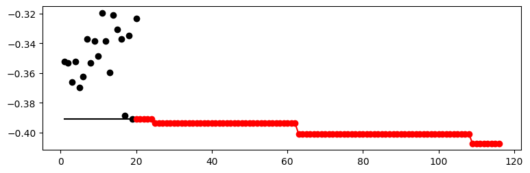

```python
#Show the Progress Result of the hyperparameter tuning

spot_tuner.plot_progress(log_y=False)
```

```python
#Print tuning Result

print(gen_design_table(fun_control=fun_control, spot=spot_tuner))
```

```
| name        | type   | default   |   lower |   upper |                 tuned | transform   |   importance | stars   |
|-------------|--------|-----------|---------|---------|-----------------------|-------------|--------------|---------|
| C           | float  | 1.0       |     0.1 |    10.0 |    1.1865329627153145 | None        |        28.83 | *       |
| kernel      | factor | rbf       |     0.0 |     0.0 |                   0.0 | None        |         0.00 |         |
| degree      | int    | 3         |     3.0 |     3.0 |                   3.0 | None        |         0.00 |         |
| gamma       | factor | scale     |     0.0 |     1.0 |                   0.0 | None        |        30.80 | *       |
| coef0       | float  | 0.0       |     0.0 |     0.0 |                   0.0 | None        |         0.00 |         |
| shrinking   | factor | 0         |     0.0 |     1.0 |                   0.0 | None        |        10.93 | *       |
| probability | factor | 0         |     1.0 |     1.0 |                   1.0 | None        |         0.00 |         |
| tol         | float  | 0.001     |  0.0001 |    0.01 | 0.0012225515213617946 | None        |       100.00 | ***     |
| cache_size  | float  | 200.0     |   100.0 |   400.0 |     276.5532104086267 | None        |         0.00 |         |
| break_ties  | factor | 0         |     0.0 |     1.0 |                   0.0 | None        |         0.00 |         |
```

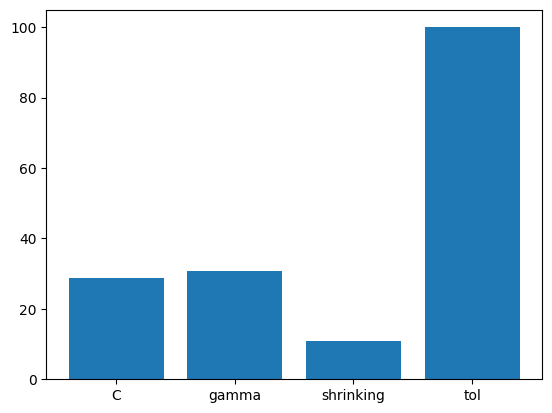

```python
# Show variable importance

spot_tuner.plot_importance(threshold=0.02)
```

#### 7.0.2.2 Display the optimal values for the hyperparameters found by spot during tuning process

Reshapes the best solution into a 2D array with a single row, as the 'to_all_dim' method expects a 2D input. Transforms the solution from the normalized space used by the tuner to the original hyperparameter space.

```python
X = spot_tuner.to_all_dim(spot_tuner.min_X.reshape(1,-1))
print(X)
```

```
[[1.18653296e+00 0.00000000e+00 3.00000000e+00 0.00000000e+00
  0.00000000e+00 0.00000000e+00 1.00000000e+00 1.22255152e-03
  2.76553210e+02 0.00000000e+00]]
```

```python
#The optimal hyperparameter values with names are returned as a dictionary and mapped to their corresponding values from X.

v_dict = assign_values(X, fun_control["var_name"])
return_conf_list_from_var_dict(var_dict=v_dict, fun_control=fun_control)
```

```
[{'C': 1.1865329627153145,
  'kernel': 'rbf',
  'degree': 3,
  'gamma': 'scale',
  'coef0': 0.0,
  'shrinking': 0,
  'probability': 1,
  'tol': 0.0012225515213617946,
  'cache_size': 276.5532104086267,
  'break_ties': 0}]
```

```python
#The function uses the values in X to set the hyperparameters of the model according to the configuration specified in fun_control
# This is to obtain the trained model that corresponds to the optimized hyperparameter values.
model_spot = get_one_sklearn_model_from_X(X, fun_control)
model_spot
```

```
SVC(C=1.1865329627153145, break_ties=0, cache_size=276.5532104086267,
    probability=1, shrinking=0, tol=0.0012225515213617946)
```

### 7.0.2.3 Training the model based on spot parameters

First, extract the feature matrix X_train & X_test and the target vector y_test & y_train from the training & testing dataset specified in the fun_control dictionary.

```python
#Fetch the data
X_train, y_train = get_Xy_from_df(fun_control["train"], fun_control["target_column"])
X_test, y_test = get_Xy_from_df(fun_control["test"], fun_control["target_column"])
X_test.shape, y_test.shape
```

```
((177, 200), (177,))
```

```python
#Fit the model with the tuned hyperparameters.
model_spot.fit(X_train, y_train)

#Predict the probabilities of the target classes for the test data 'X_test'
y_pred = model_spot.predict_proba(X_test)

#Calculate the mean average precision at k (MAP@k) score for the predictions
res = mapk_score(y_true=y_test, y_pred=y_pred, k=3)
res
```

```
0.391713747645951
```

```python
#Getting the mean & standard deviation from 30 runs

_ = repeated_eval(30, model_spot)
```

```
mean_res: 0.38647206528562456
std_res: 0.007940495581584673
min_res: 0.3644067796610169
max_res: 0.39924670433145004
median_res: 0.3870056497175141
```

### 8.0 Cross Validated Evaluations Based on Tuned Parameters

#### (a)Train subset

```python
from spotPython.sklearn.traintest import evaluate_cv
fun_control.update({
     "eval": "train_cv",
     "k_folds": 10,
})
evaluate_cv(model=model_spot, fun_control=fun_control, verbose=0)
```

```
(0.36383647798742136, None)
```

#### (b)Test subset

```python
fun_control.update({
     "eval": "test_cv",
     "k_folds": 10,
})
evaluate_cv(model=model_spot, fun_control=fun_control, verbose=0)
```

```
(0.3156862745098039, None)
```

#### (c)complete data

```python
fun_control.update({
     "eval": "data_cv",
     "k_folds": 10,
})
evaluate_cv(model=model_spot, fun_control=fun_control, verbose=0)
```

```
(0.37145204560697515, None)
```

#### 9.0 Visualizing the Top 3 Predictions on the X_test

```python
# Display the predictions for the first 10 samples
class_labels = model_spot.classes_
for i in range(10):
    sample_predictions = y_pred[i]
    top3_indices = np.argsort(-sample_predictions)[:3]
    predicted_labels = enc.inverse_transform(top3_indices.reshape(-1, 1))
    top3_predictions = [predicted_labels[j][0] for j in range(3)]
    print(f"Top 3 predictions for sample {i+1}: {top3_predictions}")
```

```
Top 3 predictions for sample 1: ['Tungiasis', 'Rift_Valley_fever', 'Dengue']
Top 3 predictions for sample 2: ['West_Nile_fever', 'Japanese_encephalitis', 'Rift_Valley_fever']
Top 3 predictions for sample 3: ['Chikungunya', 'Dengue', 'Rift_Valley_fever']
Top 3 predictions for sample 4: ['Yellow_Fever', 'Zika', 'West_Nile_fever']
Top 3 predictions for sample 5: ['Chikungunya', 'Dengue', 'Rift_Valley_fever']
Top 3 predictions for sample 6: ['Lyme_disease', 'Plague', 'West_Nile_fever']
Top 3 predictions for sample 7: ['Yellow_Fever', 'Zika', 'West_Nile_fever']
Top 3 predictions for sample 8: ['Yellow_Fever', 'Zika', 'West_Nile_fever']
Top 3 predictions for sample 9: ['West_Nile_fever', 'Japanese_encephalitis', 'Rift_Valley_fever']
Top 3 predictions for sample 10: ['Dengue', 'Tungiasis', 'Rift_Valley_fever']
```

### 10.0 Detailed Hyperparameter Contour Plots

```
C:  28.832317259217646
gamma:  30.797472960834703
shrinking:  10.92701204783907
tol:  100.0
```

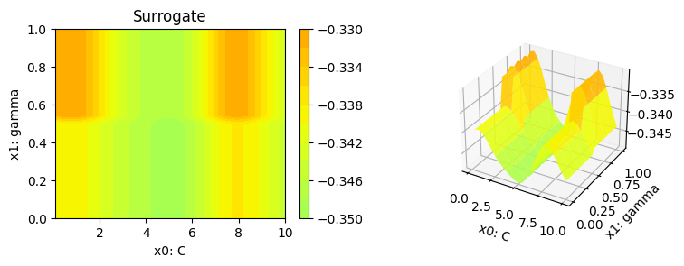

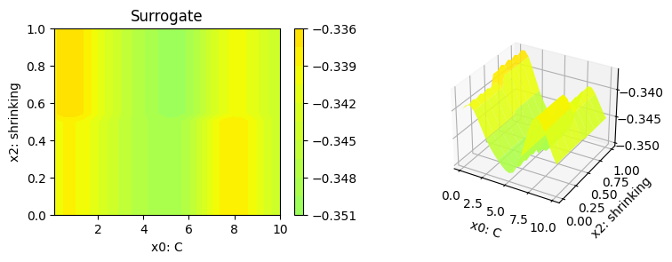

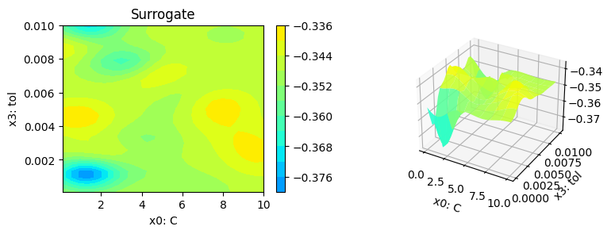

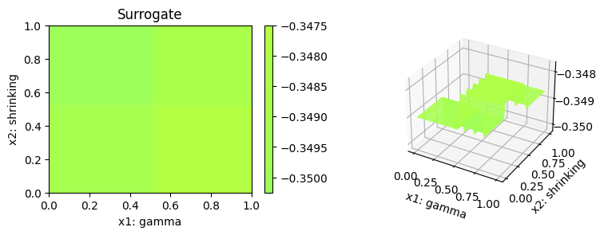

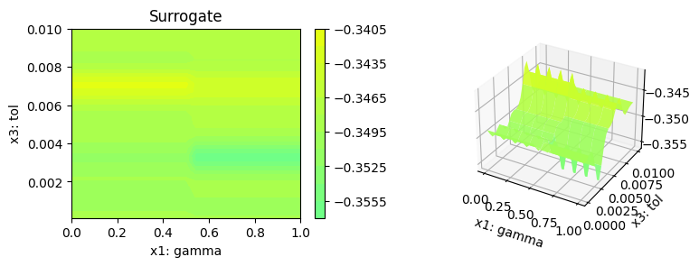

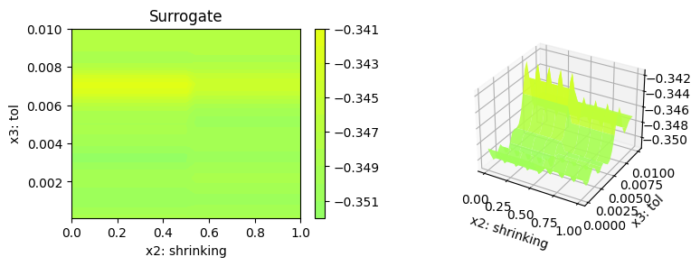

```python
spot_tuner.plot_important_hyperparameter_contour(threshold=0.025)
```

### 11.0 Top 3 Predictions on the Test.csv

```python
test = pd.read_csv('test.csv')
    # remove the id column
test = test.drop(columns=['id'])
n_samples = test.shape[0] # Number of samples/rows in the dataset(707)
n_features = test.shape[1] # Number of features/columns in the dataset(64)
#n_features
len(test.columns)
```

```
64
```

```python
test.columns = [f"x{i+1}" for i in range(n_features)] #Assigns new column names to the dataset.
print(test.shape)
test.head()
```

```
(303, 64)
```

|  | x1 | x2 | x3 | x4 | x5 | x6 | x7 | x8 | x9 | x10 | ... | x55 | x56 | x57 | x58 | x59 | x60 | x61 | x62 | x63 | x64 |
| --- | --- | --- | --- | --- | --- | --- | --- | --- | --- | --- | --- | --- | --- | --- | --- | --- | --- | --- | --- | --- | --- |
| 0 | 0.0 | 0.0 | 0.0 | 0.0 | 0.0 | 0.0 | 0.0 | 0.0 | 0.0 | 1.0 | ... | 0.0 | 0.0 | 0.0 | 0.0 | 0.0 | 0.0 | 0.0 | 0.0 | 0.0 | 0.0 |
| 1 | 1.0 | 1.0 | 0.0 | 1.0 | 0.0 | 1.0 | 1.0 | 1.0 | 1.0 | 1.0 | ... | 0.0 | 0.0 | 0.0 | 0.0 | 0.0 | 0.0 | 0.0 | 0.0 | 0.0 | 0.0 |
| 2 | 1.0 | 1.0 | 0.0 | 1.0 | 1.0 | 1.0 | 1.0 | 0.0 | 1.0 | 0.0 | ... | 0.0 | 0.0 | 0.0 | 0.0 | 0.0 | 1.0 | 0.0 | 0.0 | 0.0 | 0.0 |
| 3 | 0.0 | 1.0 | 0.0 | 0.0 | 0.0 | 1.0 | 1.0 | 1.0 | 0.0 | 0.0 | ... | 0.0 | 0.0 | 0.0 | 0.0 | 0.0 | 0.0 | 0.0 | 0.0 | 0.0 | 0.0 |
| 4 | 0.0 | 0.0 | 1.0 | 0.0 | 1.0 | 1.0 | 0.0 | 0.0 | 1.0 | 1.0 | ... | 0.0 | 0.0 | 0.0 | 0.0 | 0.0 | 0.0 | 0.0 | 0.0 | 0.0 | 0.0 |

5 rows × 64 columns

```python
test = test.astype(int)#Ensures that all the feature elements are represented as integers.
for col1, col2 in itertools.combinations(test.columns,2):#Uses the combinations function from the itertools module to generate pairs of column names.
    test[f'{col1}_and_{col2}'] = test[col1] & test[col2]#creates a new column in the dataset between the values in col1 and col2
    test[f'{col1}_or_{col2}'] = test[col1] | test[col2]#creates another new column in the dataset between the values in col1 and col2
    test[f'{col1}_xor_{col2}'] = test[col1] ^ test[col2]#creates yet another new column in the dataset between the values in col1 and col2

test
```

|  | x1 | x2 | x3 | x4 | x5 | x6 | x7 | x8 | x9 | x10 | ... | x61_xor_x64 | x62_and_x63 | x62_or_x63 | x62_xor_x63 | x62_and_x64 | x62_or_x64 | x62_xor_x64 | x63_and_x64 | x63_or_x64 | x63_xor_x64 |
| --- | --- | --- | --- | --- | --- | --- | --- | --- | --- | --- | --- | --- | --- | --- | --- | --- | --- | --- | --- | --- | --- |
| 0 | 0 | 0 | 0 | 0 | 0 | 0 | 0 | 0 | 0 | 1 | ... | 0 | 0 | 0 | 0 | 0 | 0 | 0 | 0 | 0 | 0 |
| 1 | 1 | 1 | 0 | 1 | 0 | 1 | 1 | 1 | 1 | 1 | ... | 0 | 0 | 0 | 0 | 0 | 0 | 0 | 0 | 0 | 0 |
| 2 | 1 | 1 | 0 | 1 | 1 | 1 | 1 | 0 | 1 | 0 | ... | 0 | 0 | 0 | 0 | 0 | 0 | 0 | 0 | 0 | 0 |
| 3 | 0 | 1 | 0 | 0 | 0 | 1 | 1 | 1 | 0 | 0 | ... | 0 | 0 | 0 | 0 | 0 | 0 | 0 | 0 | 0 | 0 |
| 4 | 0 | 0 | 1 | 0 | 1 | 1 | 0 | 0 | 1 | 1 | ... | 0 | 0 | 0 | 0 | 0 | 0 | 0 | 0 | 0 | 0 |
| ... | ... | ... | ... | ... | ... | ... | ... | ... | ... | ... | ... | ... | ... | ... | ... | ... | ... | ... | ... | ... | ... |
| 298 | 0 | 1 | 0 | 0 | 0 | 0 | 0 | 0 | 1 | 0 | ... | 0 | 0 | 0 | 0 | 0 | 0 | 0 | 0 | 0 | 0 |
| 299 | 1 | 0 | 1 | 0 | 1 | 1 | 0 | 1 | 1 | 1 | ... | 0 | 0 | 0 | 0 | 0 | 0 | 0 | 0 | 0 | 0 |
| 300 | 1 | 0 | 0 | 1 | 1 | 0 | 1 | 1 | 1 | 1 | ... | 0 | 0 | 0 | 0 | 0 | 0 | 0 | 0 | 0 | 0 |
| 301 | 1 | 0 | 1 | 1 | 1 | 0 | 1 | 0 | 0 | 0 | ... | 0 | 0 | 0 | 0 | 0 | 0 | 0 | 0 | 0 | 0 |
| 302 | 1 | 0 | 0 | 0 | 0 | 0 | 1 | 0 | 1 | 0 | ... | 0 | 0 | 0 | 0 | 0 | 0 | 0 | 0 | 0 | 0 |

303 rows × 6112 columns

#### Feature Aggregation

```python
cols_A = test.columns[test.columns.str.contains('pain')]#creates a new variable cols_A and assigns it the column names from the dataset DataFrame that contain the substring 'pain'
cols_B = test.columns[test.columns.str.contains('inflammation')]
cols_C = test.columns[test.columns.str.contains('bleed')]
cols_D = test.columns[test.columns.str.contains('skin')]
test['cols_A'] = test[cols_A].sum(axis=1)#Calculates the sum of the columns specified by cols_A across each row using the sum method with axis=1. The result is assigned to the new column,cols_A
test['cols_B'] = test[cols_B].sum(axis=1)
test['cols_C'] = test[cols_C].sum(axis=1)
test['cols_D'] = test[cols_D].sum(axis=1)
test1 = test
test1
```

|  | x1 | x2 | x3 | x4 | x5 | x6 | x7 | x8 | x9 | x10 | ... | x62_and_x64 | x62_or_x64 | x62_xor_x64 | x63_and_x64 | x63_or_x64 | x63_xor_x64 | cols_A | cols_B | cols_C | cols_D |
| --- | --- | --- | --- | --- | --- | --- | --- | --- | --- | --- | --- | --- | --- | --- | --- | --- | --- | --- | --- | --- | --- |
| 0 | 0 | 0 | 0 | 0 | 0 | 0 | 0 | 0 | 0 | 1 | ... | 0 | 0 | 0 | 0 | 0 | 0 | 0.0 | 0.0 | 0.0 | 0.0 |
| 1 | 1 | 1 | 0 | 1 | 0 | 1 | 1 | 1 | 1 | 1 | ... | 0 | 0 | 0 | 0 | 0 | 0 | 0.0 | 0.0 | 0.0 | 0.0 |
| 2 | 1 | 1 | 0 | 1 | 1 | 1 | 1 | 0 | 1 | 0 | ... | 0 | 0 | 0 | 0 | 0 | 0 | 0.0 | 0.0 | 0.0 | 0.0 |
| 3 | 0 | 1 | 0 | 0 | 0 | 1 | 1 | 1 | 0 | 0 | ... | 0 | 0 | 0 | 0 | 0 | 0 | 0.0 | 0.0 | 0.0 | 0.0 |
| 4 | 0 | 0 | 1 | 0 | 1 | 1 | 0 | 0 | 1 | 1 | ... | 0 | 0 | 0 | 0 | 0 | 0 | 0.0 | 0.0 | 0.0 | 0.0 |
| ... | ... | ... | ... | ... | ... | ... | ... | ... | ... | ... | ... | ... | ... | ... | ... | ... | ... | ... | ... | ... | ... |
| 298 | 0 | 1 | 0 | 0 | 0 | 0 | 0 | 0 | 1 | 0 | ... | 0 | 0 | 0 | 0 | 0 | 0 | 0.0 | 0.0 | 0.0 | 0.0 |
| 299 | 1 | 0 | 1 | 0 | 1 | 1 | 0 | 1 | 1 | 1 | ... | 0 | 0 | 0 | 0 | 0 | 0 | 0.0 | 0.0 | 0.0 | 0.0 |
| 300 | 1 | 0 | 0 | 1 | 1 | 0 | 1 | 1 | 1 | 1 | ... | 0 | 0 | 0 | 0 | 0 | 0 | 0.0 | 0.0 | 0.0 | 0.0 |
| 301 | 1 | 0 | 1 | 1 | 1 | 0 | 1 | 0 | 0 | 0 | ... | 0 | 0 | 0 | 0 | 0 | 0 | 0.0 | 0.0 | 0.0 | 0.0 |
| 302 | 1 | 0 | 0 | 0 | 0 | 0 | 1 | 0 | 1 | 0 | ... | 0 | 0 | 0 | 0 | 0 | 0 | 0.0 | 0.0 | 0.0 | 0.0 |

303 rows × 6116 columns

#### Feature Subset Selection

```python
# Get the selected feature indices and names
selected_indices = selector.get_support(indices=True)
selected_features = test1.columns[selected_indices]
len(selected_features)
```

```
200
```

```python
# Filter the dataset with the selected features
selected_data = test1[selected_features]#Creates a new dataframe containing only the selected features
#selected_data['prognosis'] = y_col #copies the target variable (prognosis) into the selected_data DataFrame.
#selected_data = selected_data.copy()
selected_data
```

|  | x36 | x60 | x61 | x62 | x2_and_x56 | x2_and_x58 | x3_and_x56 | x3_and_x58 | x3_and_x59 | x14_and_x28 | ... | x61_and_x62 | x61_or_x62 | x61_or_x63 | x61_xor_x63 | x61_or_x64 | x61_xor_x64 | x62_or_x63 | x62_xor_x63 | x62_or_x64 | x62_xor_x64 |
| --- | --- | --- | --- | --- | --- | --- | --- | --- | --- | --- | --- | --- | --- | --- | --- | --- | --- | --- | --- | --- | --- |
| 0 | 0 | 0 | 0 | 0 | 0 | 0 | 0 | 0 | 0 | 0 | ... | 0 | 0 | 0 | 0 | 0 | 0 | 0 | 0 | 0 | 0 |
| 1 | 0 | 0 | 0 | 0 | 0 | 0 | 0 | 0 | 0 | 0 | ... | 0 | 0 | 0 | 0 | 0 | 0 | 0 | 0 | 0 | 0 |
| 2 | 0 | 1 | 0 | 0 | 0 | 0 | 0 | 0 | 0 | 0 | ... | 0 | 0 | 0 | 0 | 0 | 0 | 0 | 0 | 0 | 0 |
| 3 | 0 | 0 | 0 | 0 | 0 | 0 | 0 | 0 | 0 | 0 | ... | 0 | 0 | 0 | 0 | 0 | 0 | 0 | 0 | 0 | 0 |
| 4 | 1 | 0 | 0 | 0 | 0 | 0 | 0 | 0 | 0 | 0 | ... | 0 | 0 | 0 | 0 | 0 | 0 | 0 | 0 | 0 | 0 |
| ... | ... | ... | ... | ... | ... | ... | ... | ... | ... | ... | ... | ... | ... | ... | ... | ... | ... | ... | ... | ... | ... |
| 298 | 1 | 0 | 0 | 0 | 0 | 0 | 0 | 0 | 0 | 0 | ... | 0 | 0 | 0 | 0 | 0 | 0 | 0 | 0 | 0 | 0 |
| 299 | 1 | 0 | 0 | 0 | 0 | 0 | 0 | 0 | 0 | 1 | ... | 0 | 0 | 0 | 0 | 0 | 0 | 0 | 0 | 0 | 0 |
| 300 | 1 | 0 | 0 | 0 | 0 | 0 | 0 | 0 | 0 | 0 | ... | 0 | 0 | 0 | 0 | 0 | 0 | 0 | 0 | 0 | 0 |
| 301 | 0 | 0 | 0 | 0 | 0 | 0 | 0 | 1 | 0 | 0 | ... | 0 | 0 | 0 | 0 | 0 | 0 | 0 | 0 | 0 | 0 |
| 302 | 1 | 0 | 0 | 0 | 0 | 0 | 0 | 0 | 0 | 0 | ... | 0 | 0 | 0 | 0 | 0 | 0 | 0 | 0 | 0 | 0 |

303 rows × 200 columns

```python
y_pred1 = model_default.predict_proba(selected_data)
#y_pred1
```

```python
class_labels = model_default.classes_
for i in range(707, 1010):
    # Assuming y_pred contains the predictions for all data samples
    sample_predictions = y_pred1[i-707]  # Adjust the index to match the data sample
    top3_indices = np.argsort(-sample_predictions)[:3]
    predicted_labels = enc.inverse_transform(top3_indices.reshape(-1, 1))
    top3_predictions = [predicted_labels[j][0] for j in range(3)]
    print(f"{i}: {top3_predictions}")
    #print(f"Indices: {top3_indices}")
```

```
707: ['Rift_Valley_fever', 'West_Nile_fever', 'Japanese_encephalitis']
708: ['Chikungunya', 'Dengue', 'Rift_Valley_fever']
709: ['Rift_Valley_fever', 'Japanese_encephalitis', 'West_Nile_fever']
710: ['West_Nile_fever', 'Japanese_encephalitis', 'Rift_Valley_fever']
711: ['Yellow_Fever', 'West_Nile_fever', 'Zika']
712: ['Zika', 'Yellow_Fever', 'Japanese_encephalitis']
713: ['Plague', 'Japanese_encephalitis', 'West_Nile_fever']
714: ['Dengue', 'Rift_Valley_fever', 'West_Nile_fever']
715: ['Zika', 'Yellow_Fever', 'Japanese_encephalitis']
716: ['West_Nile_fever', 'Plague', 'Zika']
717: ['West_Nile_fever', 'Yellow_Fever', 'Japanese_encephalitis']
718: ['West_Nile_fever', 'Japanese_encephalitis', 'Rift_Valley_fever']
719: ['West_Nile_fever', 'Japanese_encephalitis', 'Rift_Valley_fever']
720: ['Chikungunya', 'Dengue', 'Rift_Valley_fever']
721: ['West_Nile_fever', 'Plague', 'Japanese_encephalitis']
```

[output cut: 288 more lines]

```python
# Create a list to store the top 3 predictions
predictions = []

for i in range(707, 1010):
    # Assuming y_pred contains the predictions for all data samples
    sample_predictions = y_pred1[i-707]  # Adjust the index to match the data sample
    top3_indices = np.argsort(-sample_predictions)[:3]
    predicted_labels = enc.inverse_transform(top3_indices.reshape(-1, 1))
    top3_predictions = [predicted_labels[j][0] for j in range(3)]
    predictions.append(top3_predictions)
```

```python
# Create a DataFrame with index and top 3 predictions
submission_df = pd.DataFrame({
    'id': range(707, 1010),
    'Prognosis': predictions
})
```

```python
# Save the DataFrame to submission.csv with only the 'id' and 'Prognosis' columns
submission_df.to_csv('submission.csv', columns=['id', 'Prognosis'], index=False)
```

```python
ty = pd.read_csv('submission.csv')
```